# Homework 2

# Submission Instructions

- Please submit your responses as a nicely formatted notebook (.ipynb) file.
- For questions that require calculations:
  - Show your work (i.e., show the R code you used to answer the question).
  - Make sure all the code you used to answer the question has been run (i.e., displays an output) otherwise you will get a zero for that question.
  - If your *answer* includes many decimal places (e.g., 3.14159265358979), please round it to a reasonable number of decimals for readability (typically 3 to 5).
  - There should be no rounding inside the calculations you do, only round the final result if necessary.
  - For ease of marking, avoid showing the outputs of unnecessary values.

# Question 1

## Calculate $\bar{x}$, $\text{ss}$, $s^2$, and $s$ of the following data. You are not allowed to use the functions `mean()`, `sd()`, or `var()`.

$$650, 670, 660, 669, 649, 668, 677, 651,
680, 663$$

# Question 2

## Assuming the data from the previous question is normally distributed, calculate the points the middle 95% of the data fall within. Do not use the functions `pnorm()` or `qnorm()`; instead, use the graph below (from the lecture) to determine the middle boundry.

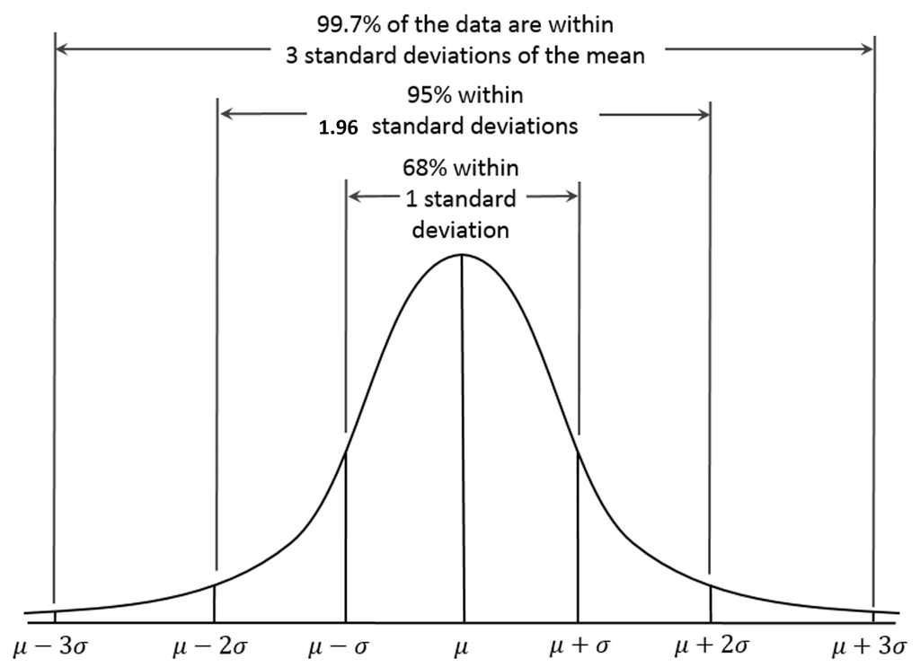

# Question 3

Assuming the data from question 1 is normally distributed, calculate the points the middle 68% of the data fall within. Do not use the functions `pnorm()` or `qnorm()`; instead, use the graph provided in the previous question.

# Question 4

Calculate $\mu$, $\text{ss}$, $\sigma^2$, and $\sigma$ for the following distribution of numbers:

### $$4, 4, 4, 4, 4, 4, 4$$

Why do you think the answer turned out the way it did? You are NOT allowed to use the function `mean()`, `sd()`, or `var()`.

# Question 5

Which of the following are measures of spread?

- Range
- IQR
- Quartiles
- Median
- Mean
- Sum of Squared Deviations
- Variance
- Standard Deviation
- Z-score

# Question 6

Using the Son height data from the lecture, transform the sons’ scores to have a mean of 500 and a standard deviation of 500. Then plot a histogram of the new distribution with an interesting fill and edge colour. Label the x-axis and y-axis “*New Son Heights*” and “*Frequency*” respectively.

# Question 7

From the course website, download the dataset **Pokemon.csv**. This data set presents statistics for each of the pokémon characters in the popular video game franchise “Pokémon.”

Use this data set to plot a density plot for the variable “HP.” Give the density plot a fill colour of “Pikachu yellow”, which is defined by Nintendo as “#F6CF57.”

- HP stands for hit points, or health points, and defines how much damage a pokémon can withstand before fainting.
- Fun Fact: Some of the columns in this dataset contain Japanese characters. If you open this in Microsoft Excel, there is a good chance they won’t display properly. This is because, by default, Microsoft Excel does not read CSV files using [UTF-8 character encoding](https://blog.hubspot.com/website/what-is-utf-8) despite that being the accepted standard. Why? I don’t know - but it is probably because they want you to use .xlsx files and could care less about anything that doesn’t belong to Microsoft. Note, if you want a spreadsheet software that will use UTF-8 character encoding by default, try [Libre Office](https://www.libreoffice.org/) or even Google Sheets.

# Question 8

Plot a Q-Q plot of the pokémon HP column and indicate whether or not you believe the data is normally distributed (describe why you believe this - appeal to both the density and Q-Q plot).

Make sure the Q-Q-plot incorporates Pikachu yellow in some way.

# Question 9

Use Tukey’s Ladder of Powers to find a transformation that makes the pokémon HP data more normal/Gaussian. Specify which value of lambda ($\lambda$) you used and plot a histogram of the transformed data. Ensure that your x-axis label communicates the transformation you applied.

- Note: the function `transformTukey()` is NOT allowed to be used for this question. You need to experiment and walk up/down the ladder yourself. (You do not need to show all your attempts, just show the final result).
- Note: An exhaustive search for the exact value of lambda is unnecessary. Use only the values provided in the [lecture table](https://drive.google.com/file/d/1G-o50icdA7k1in8H2czNgOE7V2rIu_Mj/view?usp=drive_link).

# Question 10

Plot a Q-Q plot of your transformed pokémon HP data. Use it and the plot from the previous question to determine whether you believe the transformed data is now acceptably normal. Hint: the answer is no. Justify your answer.

# Question 11

For the variable HP, calculate the following statistics using the original (untransformed) pokémon data:

- Median
- Mean
- 20% Trimmed Mean
- Standard Deviation
- 20% Winsorized Standard Deviation

# Question 12

Without using the R function `mad()`, list the values considered outliers for the untransformed pokémon HP data according to the MAD-median rule for outlier detection.

When listing the outliers, only display the following columns: `$pokedex_number`, `$name`, and `$hp`.

# Question 13

Use the R functions `pnorm()` and `qnorm()` to answer questions a - p. Round your answers to 5 decimal places. Trailing zeros (e.g., 5.79000) do not need to be provided.

- Note that there are multiple correct ways to apply these functions for some of the questions.

## a.

What percentile is a z-score of 0 at?

## b.

What percentile is a z-score of -1.96 at?

## c.

What percentile is a z-score of 1.96 at?

## d.

What probability does a z-score of 1.96 correspond to?

## e.

What percentile is a score of 202 at for a normal distribution with a mean of 224 and standard deviation of 29?

## f.

What percentile is a score of 224 at for a normal distribution with a mean of 224 and standard deviation of 29?

## g.

What score is at the 2.5th percentile for a normal distribution with a mean of 224 and standard deviation of 29?

## h.

What score is at the 97.5th percentile for a normal distribution with a mean of 224 and standard deviation of 29?

## i.

What z-score represents the 2.5th percentile?

## j.

z-score represents the top 2.5% of a normal distribution?

## k.

What z-score is at the 97.5th percentile?

## l.

What score represents the top 2.5% of a normal distribution with a mean of 224 and standard deviation of 29?

## m.

What score represents the top 5% of a normal distribution with a mean of 224 and standard deviation of 29?

## n.

What z-score represents the top 5% of a normal distribution?

## o.

What score represents the top 5% of a normal distribution with a mean of 132 and standard deviation of 57?

## p.

What score represents the bottom 9.3% of a normal distribution with a mean of 132 and standard deviation of 57?

# Question 14

Which distribution contains the largest spread/variability?

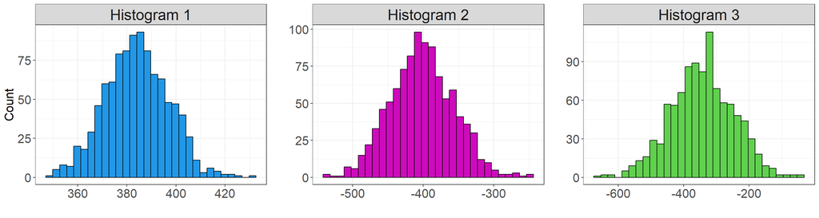

# Question 15

The following plot is a standard normal distribution. What percentile is represented by the coloured (non-grey) region.

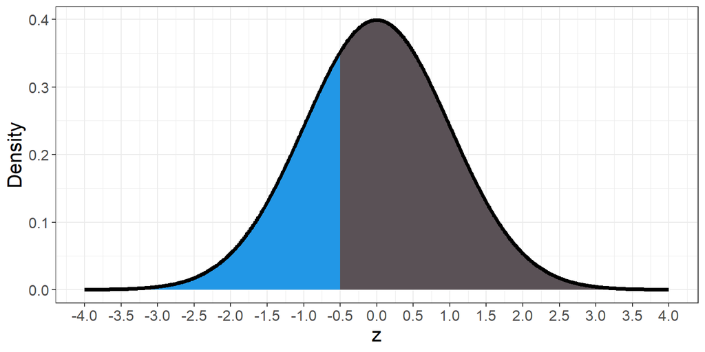

# Question 16

The following plot is a standard normal distribution. What percentile is represented by the coloured (non-grey) region.

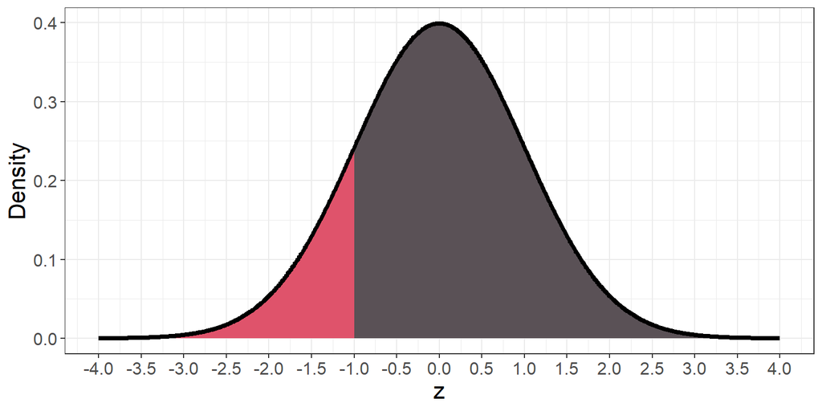

# Question 17

The following distribution has a mean of 100 and standard deviation of 15. What percentile is represented by the coloured (non-grey) region.

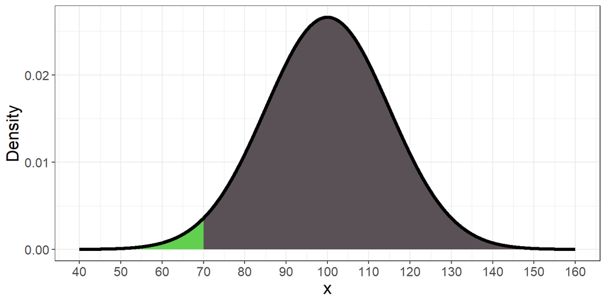

# Question 18

The following distribution has a mean of 100 and standard deviation of 15. What percentage of the data is represented by the coloured (non-grey) region.

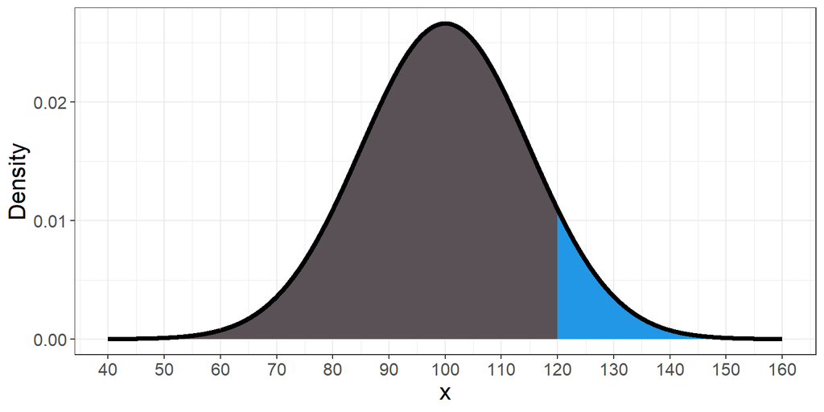

# Question 19

Bobby’s brother constantly tells him he’s abnormal. To prove this, his brother obtained a sample of test scores from Bobby’s class (Bobby was included in this sample). His classmates’ scores were 70, 68, 75, 72, 76, 74, 69, 82, 73, and Bobby scored a 56. If “abnormal” is operationally defined as being at least 2 standard deviations away from the mean, is Bobby abnormal? Assume the data follows a normal distribution.

# Question 20

From the previous question, what is the probability of a student scoring at Bobby’s mark or less?

# Question 21

What is the probability of a student scoring higher than Bobby?

# Question 22

We have sent out everyone in a large introductory course to check whether people use seat belts. Each student has been told to look at 100 cars and count the number of people wearing seat belts. The number found by any given student is considered that student’s score. The mean score for the class is 44, with a standard deviation of 7. A student who has done very little work all year has reported finding 62 seat belt users out of 100. Do we have reason to suspect that the student just made up a number rather than actually counting? Assume the data collected by the class follows a normal distribution.

# Question 23

From the previous question, what is the minimum and maximum number of seatbelts that could have been “observed” by this student without drawing suspicion? Assume anything in the top and bottom 2.5% of the distribution is suspicious. Round to the nearest seatbelt.

# Question 24

A researcher counted the number of behavioural responses a sample of participants completed during a period of operant extinction (i.e., the participaints were no longer reinforced/rewarded to perform a task). The data was positively skewed but the researcher nonetheless analyzed the results in terms of means and standard deviations. They reported a mean of $5.88$ and a standard deviation of $8.06$. Why was this an incredibly stupid way to analyze the results? Hint: consider where $0$ responses might fall if this distribution was symmetric and unimodal.

# Question 25

Recall that, for question 2 and 3 you needed to calculate the middle 95% and middle 68% boundries for the following data:

### $$650, 670, 660, 669, 649, 668, 677, 651, 680, 663$$

Do that again, but this time use R functions to obtain a more precise calculation.

# Question 26

In a normal distribution, how many standard deviations above and below the mean are the upper and lower boundaries of the middle 68% interval? Give an answer rounded to at least 4 decimal places.